# 5052 Data Visualization

Yingtong Zhou

```r
com_sample <- read.csv("~/Desktop/QMSS - CU/Spring 2020/GR5052_Practicum/complaints_sample.csv",
                       comment.char="#")
library(ggplot2)
library(dplyr)
library("tm")
library("SnowballC")
library("wordcloud")
library("RColorBrewer")
```

# Bar Charts

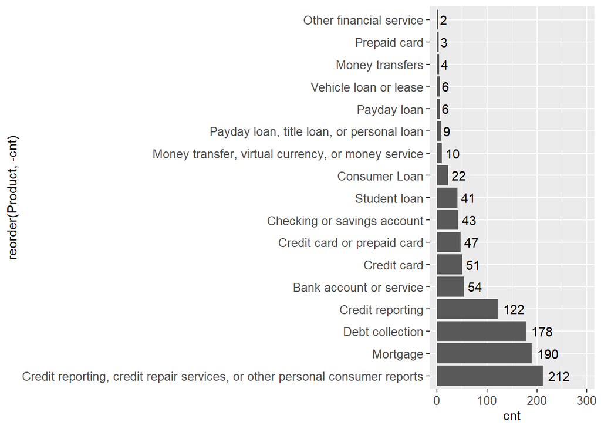

```r
#unique(com_sample$Product)

com_product <- com_sample %>%
  group_by(Product) %>%
  summarize(cnt = n()) %>%
  arrange(desc(cnt))


#levels(com_product$Product) <- gsub(",", ",\n", levels(com_product$Product))

gg_product <- ggplot(com_product, aes(x = reorder(Product, -cnt), y = cnt)) +
  geom_bar(stat = "identity") +
  scale_y_discrete(expand = c(0, 50)) +
  theme(axis.text.y = element_text(size = 10),
        axis.text.x = element_text(size = 10)) +
  geom_text(aes(label = cnt),
            hjust = -0.25,
            vjust = 0.5) +
  ylim(0, 300) +
  coord_flip()


gg_product
```

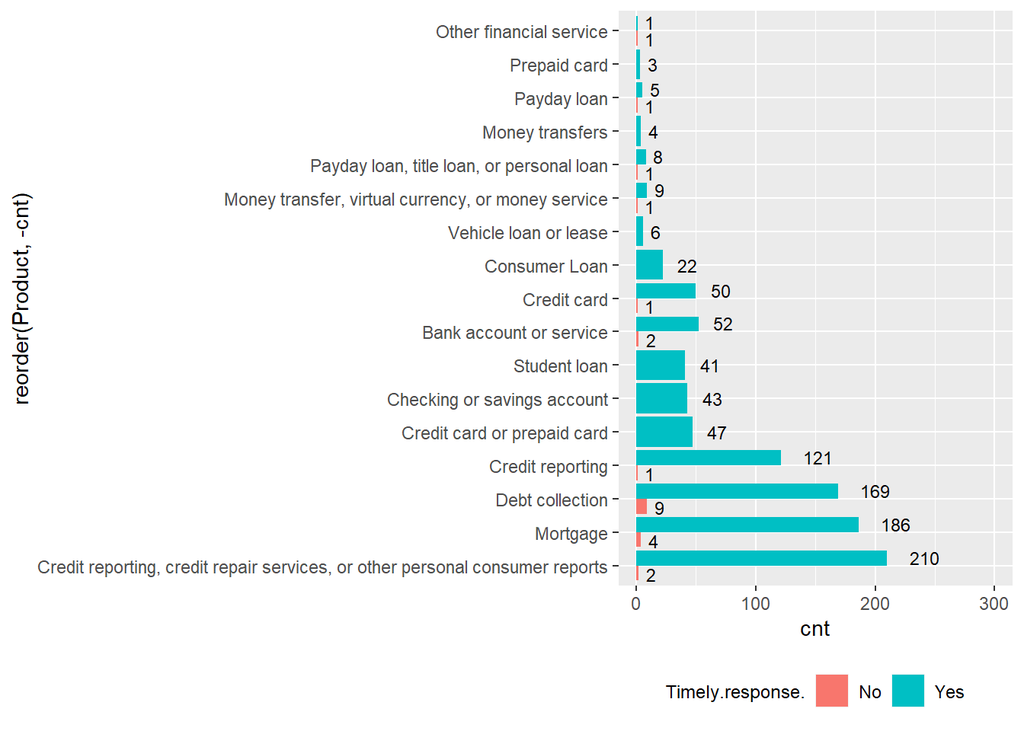

```r
com_proti <- com_sample %>%
  group_by(Product, Timely.response.) %>%
  summarize(cnt = n())

gg_proti <- ggplot(com_proti, aes(x = reorder(Product, -cnt), y = cnt, fill = Timely.response.)) +
  geom_bar(stat = "identity",position = "dodge") +
  geom_text(aes(label = cnt),
            hjust = -0.75,
            vjust = 0.5,
            position = position_dodge(width = 1),
            size = 3) +
  coord_flip() +
  ylim(0, 300) +
  theme(legend.position = "bottom",
        legend.title = element_text(size = 9))

gg_proti
```

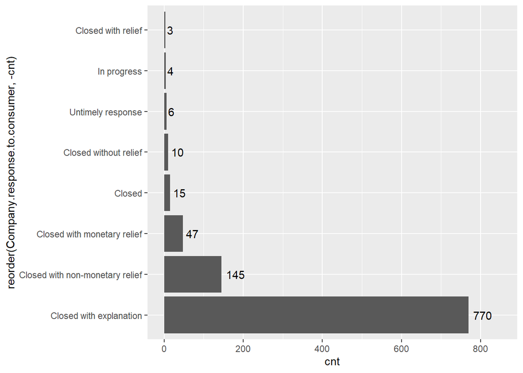

```r
#unique(com_sample$Company.response.to.consumer)

com_res <- com_sample %>%
  group_by(Company.response.to.consumer) %>%
  summarize(cnt = n()) %>%
  arrange(desc(cnt))

gg_res <- ggplot(com_res, aes(x = reorder(Company.response.to.consumer, -cnt), y = cnt)) +
  geom_bar(stat = "identity") +
  geom_text(aes(label = cnt),
            hjust = -0.25,
            vjust = 0.5) +
  coord_flip() +
  ylim(0, 850)


gg_res
```

Based on the graph regarding companies’ response to complaints, complaints were “Closed with explanation” for 77% of the time and about 15% were “Closed with non-monetary relief.” Very few cases were categorized as “Untimely response.” However, I doubt the validity of such categorization of “Untimely response,” which might be underestimated. The category of “Closed with explanation” is too broad and might fail to account for more subtle aspects of the complaints, which are closely related to customer satisfaction. Complaints might be closed but the customers might have negative experience with these products. Besides, the “Closed” category is very vague. It does not give any explanation on how the complaints were settled while this group of customers could have be angry or more information might be hidden.

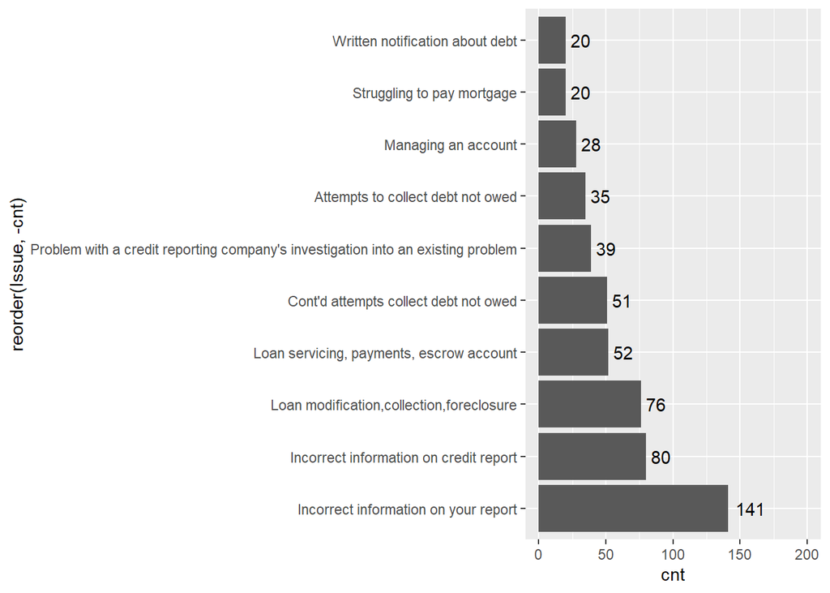

```r
#unique(com_sample$Issue)

com_iss <- com_sample %>%
  group_by(Issue) %>%
  summarize(cnt = n()) %>%
  arrange(desc(cnt)) %>%
  filter(cnt > 19)

gg_iss <- ggplot(com_iss, aes(x = reorder(Issue, -cnt), y = cnt)) +
  geom_bar(stat = "identity") +
  geom_text(aes(label = cnt),
            hjust = -0.25,
            vjust = 0.5) +
  coord_flip() +
  ylim(0, 200)


gg_iss
```

Based on the above information, I learnt that there are over 100 different issues related to the complaints and they are pretty diversely distributed. The bar chart shows the top ten issues complained. Complaints concerning incorrect information on report and credit card report are most prevalent. This is also relatively easy to solve if there is a system that better collects, records and verifies the information before presenting it to customers. It would be helpful if it would be interactive for the customers so that they are better informed and served. More effective approach or system should be incorporated so that the collection of information would be correct in the first place.

# Word Cloud

```r
nar_sam <- readLines("~/Desktop/QMSS - CU/Spring 2020/GR5052_Practicum/nar_sam.txt")

ns <- Corpus(VectorSource(nar_sam))
#inspect(ns)

toSpace <- content_transformer(function (x , pattern) gsub(pattern, " ", x))
ns <- tm_map(ns, toSpace, "/")
ns <- tm_map(ns, toSpace, "@")
ns <- tm_map(ns, toSpace, "\\|")
ns <- tm_map(ns, toSpace, "XXXX")

docs <- tm_map(ns, content_transformer(tolower))
docs <- tm_map(docs, removeNumbers)
docs <- tm_map(docs, removeWords, stopwords("english"))
docs <- tm_map(docs, removePunctuation)
docs <- tm_map(docs, stripWhitespace)
docs <- tm_map(docs, stemDocument)

dtm <- TermDocumentMatrix(docs)
m <- as.matrix(dtm)
v <- sort(rowSums(m),decreasing=TRUE)
d <- data.frame(word = names(v),freq=v)
head(d, 10)
```

|  | word | freq |
| --- | --- | --- |
| credit | credit | 547 |
| account | account | 507 |
| report | report | 455 |
| payment | payment | 368 |
| call | call | 319 |
| time | time | 214 |
| receiv | receiv | 213 |
| inform | inform | 197 |
| bank | bank | 196 |
| debt | debt | 190 |

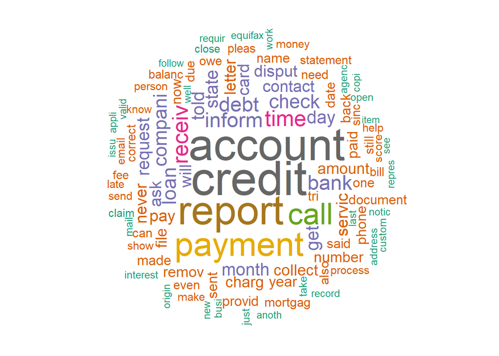

```r
set.seed(1234)
wordcloud(words = d$word, freq = d$freq, min.freq = 50,
          max.words = 200, random.order = FALSE, rot.per = 0.35,
          colors=brewer.pal(8, "Dark2"))
```

```r
freq100t <- findFreqTerms(dtm, lowfreq = 100)

findAssocs(dtm, terms = "credit", corlimit = 0.3)
```

```
## $credit
##    report     score      card   bureaus      show  experian   account
##      0.55      0.46      0.44      0.40      0.35      0.34      0.33
##     chalk       csr   element     enorm      fico      inde   misdeal
##      0.33      0.33      0.33      0.33      0.33      0.33      0.33
## underhand unexplain    whomev       yrs     never    dispar      pull
##      0.33      0.33      0.33      0.33      0.32      0.32      0.31
##       use       day      line
##      0.31      0.30      0.30
```

```r
findAssocs(dtm, terms = "account", corlimit = 0.3)
```

```
## $account
##   credit   combin consider rational    remov   disput  increas  deposit
##     0.33     0.33     0.33     0.33     0.31     0.31     0.31     0.31
##   report    check
##     0.30     0.30
```

The wordcloud is generated from the customer narratives. The most frequent words are “credit,” “account,” “payment,” and “report.” They are consistent with the issue and product types of the complaints. The “findAssocs” function shows the terms that are often associated with the two most popular narrative terms. Among the associated terms of “credit,” “experian” has a relatively high occurrence probably due to its numerous services related to credit.